```python
import numpy as np # linear algebra
import pandas as pd # data processing, CSV file I/O (e.g. pd.read_csv)
import matplotlib.pyplot as plt
import matplotlib
import seaborn as sns
from sklearn.preprocessing import StandardScaler
from sklearn.cluster import KMeans

import warnings
warnings.filterwarnings(action="ignore")
%matplotlib inline
warnings.filterwarnings("ignore")
matplotlib.rcParams['font.sans-serif'] = ['SimHei']
matplotlib.rcParams['axes.unicode_minus'] = False
```

```python
data = pd.read_csv("C:/Users/zhang/Desktop/ccdata/CC GENERAL.csv")
```

```python
len(data)
```

```
8950
```

- 数据量为8950

```python
data.columns
```

```
Index(['CUST_ID', 'BALANCE', 'BALANCE_FREQUENCY', 'PURCHASES',
       'ONEOFF_PURCHASES', 'INSTALLMENTS_PURCHASES', 'CASH_ADVANCE',
       'PURCHASES_FREQUENCY', 'ONEOFF_PURCHASES_FREQUENCY',
       'PURCHASES_INSTALLMENTS_FREQUENCY', 'CASH_ADVANCE_FREQUENCY',
       'CASH_ADVANCE_TRX', 'PURCHASES_TRX', 'CREDIT_LIMIT', 'PAYMENTS',
       'MINIMUM_PAYMENTS', 'PRC_FULL_PAYMENT', 'TENURE'],
      dtype='object')
```

```python
len(data.columns)
```

```
18
```

- 一共18个特征

特征的含义：

- CUST_ID：客户ID
- BALANCE：余额
- BALANCE_FREQUENCY：余额变动的频率(0-1,1是频繁更新，0是完全不更新)
- PURCHASES：购买
- ONEOFF_PURCHASES：一次性付款
- INSTALLMENTS_PURCHASES：分期付款
- CASH_ADVANCE：预付现金
- PURCHASES_FREQUENCY：购买频率
- ONEOFF_PURCHASES_FREQUENCY：一次性购买频率
- PURCHASES_INSTALLMENTS_FREQUENCY：分期付款购买频率
- CASH_ADVANCE_FREQUENCY：预付现金频率
- CASH_ADVANCE_TRX：？
- PURCHASES_TRX：？
- CREDIT_LIMIT：信用限额
- PAYMENTS：付款
- MINIMUM_PAYMENTS：最低付款
- PRC_FULL_PAYMENT：全额付款
- TENURE：还款期限

```python
data.isnull().sum().sort_values(ascending=False)
```

```
MINIMUM_PAYMENTS                    313
CREDIT_LIMIT                          1
TENURE                                0
PURCHASES_FREQUENCY                   0
BALANCE                               0
BALANCE_FREQUENCY                     0
PURCHASES                             0
ONEOFF_PURCHASES                      0
INSTALLMENTS_PURCHASES                0
CASH_ADVANCE                          0
ONEOFF_PURCHASES_FREQUENCY            0
PRC_FULL_PAYMENT                      0
PURCHASES_INSTALLMENTS_FREQUENCY      0
CASH_ADVANCE_FREQUENCY                0
CASH_ADVANCE_TRX                      0
PURCHASES_TRX                         0
PAYMENTS                              0
CUST_ID                               0
dtype: int64
```

- 上面检测了缺失值，发现只有MINIMUM_PAYMENTS和CREDIT_LIMIT中存在缺失值，可以使用均值进行填充

```python
data['MINIMUM_PAYMENTS'].fillna(data.MINIMUM_PAYMENTS.mean(),inplace=True)
data['CREDIT_LIMIT'].fillna(data.CREDIT_LIMIT.mean(),inplace=True)
```

下面查找异常值

```python
#显示数据的各种统计量信息
data.describe()
```

|  | BALANCE | BALANCE_FREQUENCY | PURCHASES | ONEOFF_PURCHASES | INSTALLMENTS_PURCHASES | CASH_ADVANCE | PURCHASES_FREQUENCY | ONEOFF_PURCHASES_FREQUENCY | PURCHASES_INSTALLMENTS_FREQUENCY | CASH_ADVANCE_FREQUENCY | CASH_ADVANCE_TRX | PURCHASES_TRX | CREDIT_LIMIT | PAYMENTS | MINIMUM_PAYMENTS | PRC_FULL_PAYMENT | TENURE |
| --- | --- | --- | --- | --- | --- | --- | --- | --- | --- | --- | --- | --- | --- | --- | --- | --- | --- |
| count | 8950.000000 | 8950.000000 | 8950.000000 | 8950.000000 | 8950.000000 | 8950.000000 | 8950.000000 | 8950.000000 | 8950.000000 | 8950.000000 | 8950.000000 | 8950.000000 | 8950.000000 | 8950.000000 | 8950.000000 | 8950.000000 | 8950.000000 |
| mean | 1564.474828 | 0.877271 | 1003.204834 | 592.437371 | 411.067645 | 978.871112 | 0.490351 | 0.202458 | 0.364437 | 0.135144 | 3.248827 | 14.709832 | 4494.449450 | 1733.143852 | 864.206542 | 0.153715 | 11.517318 |
| std | 2081.531879 | 0.236904 | 2136.634782 | 1659.887917 | 904.338115 | 2097.163877 | 0.401371 | 0.298336 | 0.397448 | 0.200121 | 6.824647 | 24.857649 | 3638.612411 | 2895.063757 | 2330.588021 | 0.292499 | 1.338331 |
| min | 0.000000 | 0.000000 | 0.000000 | 0.000000 | 0.000000 | 0.000000 | 0.000000 | 0.000000 | 0.000000 | 0.000000 | 0.000000 | 0.000000 | 50.000000 | 0.000000 | 0.019163 | 0.000000 | 6.000000 |
| 25% | 128.281915 | 0.888889 | 39.635000 | 0.000000 | 0.000000 | 0.000000 | 0.083333 | 0.000000 | 0.000000 | 0.000000 | 0.000000 | 1.000000 | 1600.000000 | 383.276166 | 170.857654 | 0.000000 | 12.000000 |
| 50% | 873.385231 | 1.000000 | 361.280000 | 38.000000 | 89.000000 | 0.000000 | 0.500000 | 0.083333 | 0.166667 | 0.000000 | 0.000000 | 7.000000 | 3000.000000 | 856.901546 | 335.628312 | 0.000000 | 12.000000 |
| 75% | 2054.140036 | 1.000000 | 1110.130000 | 577.405000 | 468.637500 | 1113.821139 | 0.916667 | 0.300000 | 0.750000 | 0.222222 | 4.000000 | 17.000000 | 6500.000000 | 1901.134317 | 864.206542 | 0.142857 | 12.000000 |
| max | 19043.138560 | 1.000000 | 49039.570000 | 40761.250000 | 22500.000000 | 47137.211760 | 1.000000 | 1.000000 | 1.000000 | 1.500000 | 123.000000 | 358.000000 | 30000.000000 | 50721.483360 | 76406.207520 | 1.000000 | 12.000000 |

- 可以看出每个特征的取值范围都是不一样的，而且有的特征之间的取值范围差距是很大的，所以像这样的数值在输入到模型之前需要进行处理，否则会影响到模型的输出结果

下面用箱型图

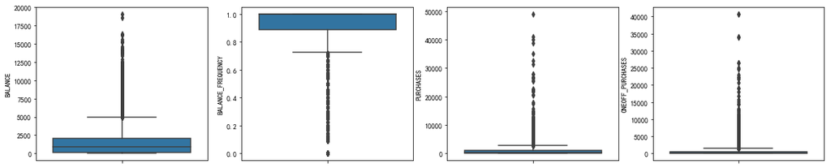

```python
f,axes = plt.subplots(ncols=4,figsize=(20,4))

sns.boxplot(y='BALANCE',data=data,ax=axes[0])
sns.boxplot(y='BALANCE_FREQUENCY',data=data,ax=axes[1])
sns.boxplot(y='PURCHASES',data=data,ax=axes[2])
sns.boxplot(y='ONEOFF_PURCHASES',data=data,ax=axes[3])
```

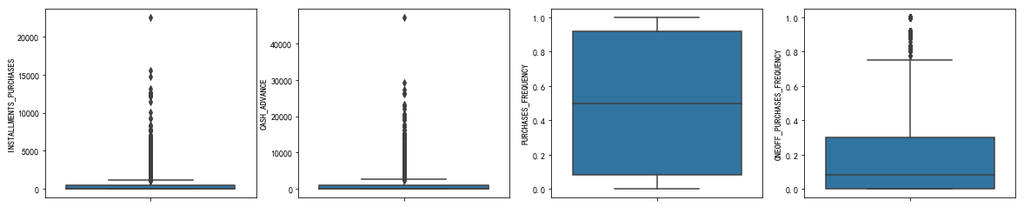

```python
f,axes = plt.subplots(ncols=4,figsize=(20,4))

sns.boxplot(y='INSTALLMENTS_PURCHASES',data=data,ax=axes[0])
sns.boxplot(y='CASH_ADVANCE',data=data,ax=axes[1])
sns.boxplot(y='PURCHASES_FREQUENCY',data=data,ax=axes[2])
sns.boxplot(y='ONEOFF_PURCHASES_FREQUENCY',data=data,ax=axes[3])
```

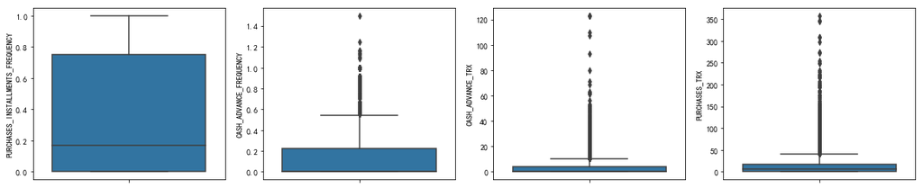

```python
f,axes = plt.subplots(ncols=4,figsize=(20,4))

sns.boxplot(y='PURCHASES_INSTALLMENTS_FREQUENCY',data=data,ax=axes[0])
sns.boxplot(y='CASH_ADVANCE_FREQUENCY',data=data,ax=axes[1])
sns.boxplot(y='CASH_ADVANCE_TRX',data=data,ax=axes[2])
sns.boxplot(y='PURCHASES_TRX',data=data,ax=axes[3])
```

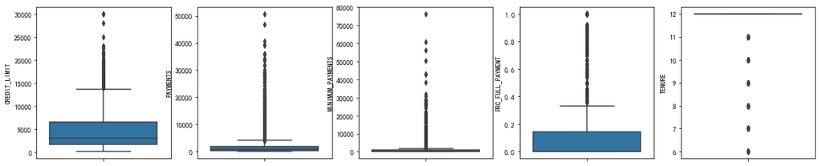

```python
f,axes = plt.subplots(ncols=5,figsize=(20,4))

sns.boxplot(y='CREDIT_LIMIT',data=data,ax=axes[0])
sns.boxplot(y='PAYMENTS',data=data,ax=axes[1])
sns.boxplot(y='MINIMUM_PAYMENTS',data=data,ax=axes[2])
sns.boxplot(y='PRC_FULL_PAYMENT',data=data,ax=axes[3])
sns.boxplot(y='TENURE',data=data,ax=axes[4])
```

- 从上面的可视化结果可以看出，各个特征中都存在很多的异常值，但是这些异常值可能都是合理存在的，并不是那种错误的值，所以不应该进行剔除，而是使用转换等方式进行处理

根据不同的取值进行不同的转换

- 对下面这些特征设置不同的区间，然后根据区间范围进行转换处理

```python
columns=['BALANCE', 'PURCHASES', 'ONEOFF_PURCHASES', 'INSTALLMENTS_PURCHASES', 'CASH_ADVANCE', 'CREDIT_LIMIT',
         'PAYMENTS', 'MINIMUM_PAYMENTS']

for column in columns:
    new = 'new_' + column
    data[new] = 0
    data.loc[((data[column]>0)&(data[column]<=5000)),new] = 1
    data.loc[((data[column]>5000)&(data[column]<=10000)),new] = 2
    data.loc[((data[column]>10000)),new] = 3
```

```python
columns=['BALANCE_FREQUENCY', 'PURCHASES_FREQUENCY', 'ONEOFF_PURCHASES_FREQUENCY', 'PURCHASES_INSTALLMENTS_FREQUENCY',
         'CASH_ADVANCE_FREQUENCY', 'PRC_FULL_PAYMENT']

for column in columns:
    new = 'new_' + column
    data[new]=0
    data.loc[((data[column]>0)&(data[column]<=0.4)),new] = 1
    data.loc[((data[column]>0.4)&(data[column]<=0.6)),new] = 2
    data.loc[((data[column]>0.6)&(data[column]<=1)),new] = 3
```

```python
columns=['PURCHASES_TRX', 'CASH_ADVANCE_TRX']

for column in columns:
    new = 'new_' + column
    data[new]=0
    data.loc[((data[column]>0)&(data[column]<=40)),new] = 1
    data.loc[((data[column]>40)&(data[column]<=60)),new] = 2
    data.loc[((data[column]>60)&(data[column]<=100)),new] = 3
```

```python
#删除原始数据的特征
data.drop(['CUST_ID', 'BALANCE', 'BALANCE_FREQUENCY', 'PURCHASES',
           'ONEOFF_PURCHASES', 'INSTALLMENTS_PURCHASES', 'CASH_ADVANCE',
           'PURCHASES_FREQUENCY', 'ONEOFF_PURCHASES_FREQUENCY',
           'PURCHASES_INSTALLMENTS_FREQUENCY', 'CASH_ADVANCE_FREQUENCY',
           'CASH_ADVANCE_TRX', 'PURCHASES_TRX', 'CREDIT_LIMIT', 'PAYMENTS',
           'MINIMUM_PAYMENTS', 'PRC_FULL_PAYMENT' ], axis=1, inplace=True)

X = np.asarray(data)
```

```python
#标准化处理，不改变数据形状
from sklearn.preprocessing import StandardScaler

scale = StandardScaler()
X = scale.fit_transform(X)
```

数据处理结束后就可以带入到模型中进行处理了，而我的目的是对客户进行分群，所以可以使用聚类算法，但是并不能确定要设定多大的簇类数，所以设定了一个范围，然后在指定范围内找出最好的簇类数目

```python
n_clusters = 30
cost = []
new_cost = []

for i in range(1,n_clusters):
    kmeans = KMeans(i)
    kmeans.fit(X)
    labels = kmeans.labels_
    cost.append(kmeans.inertia_)
    #new_cost.append(metrics.silhouette_score(X,labels,metric='euclidean'))
```

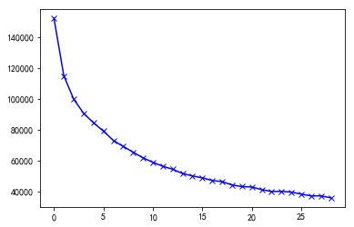

```python
plt.plot(cost, 'bx-')
```

```python
kmeans = KMeans(6)
kmeans.fit(X)
labels = kmeans.labels_
```

```python
df_data = data.copy()
df_data = pd.concat([df_data,pd.DataFrame({'labels':labels})],axis=1)
```

下面分析一下聚类之后的效果到底怎么样

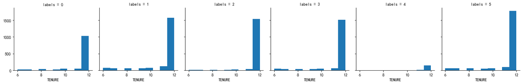

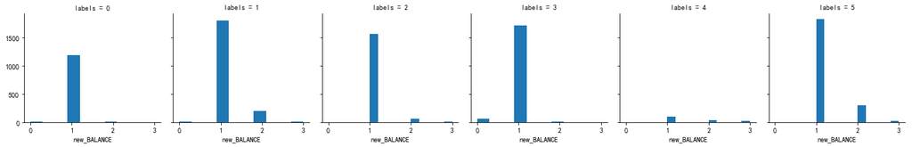

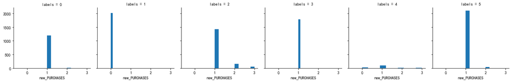

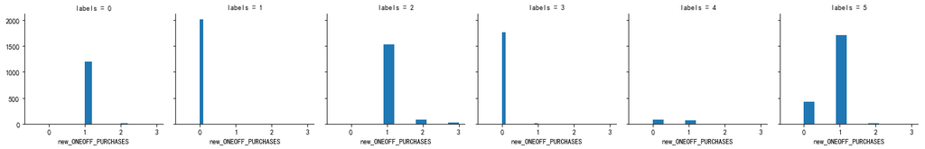

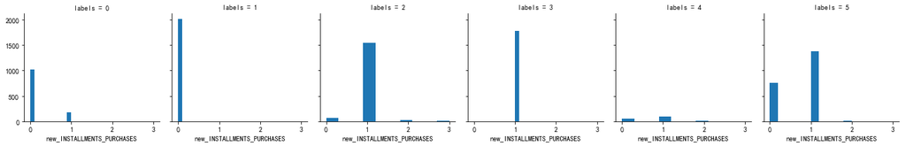

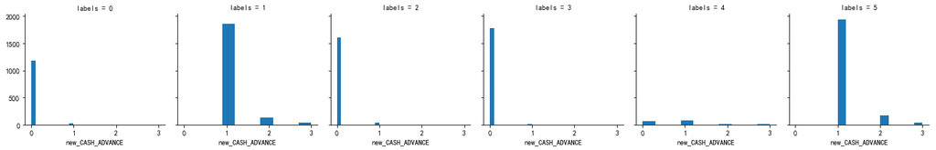

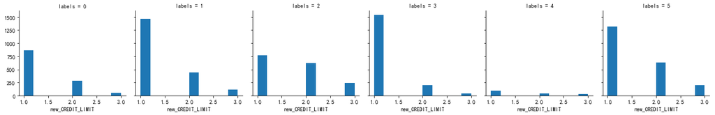

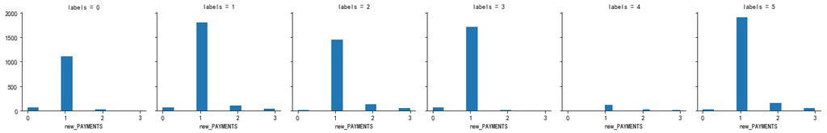

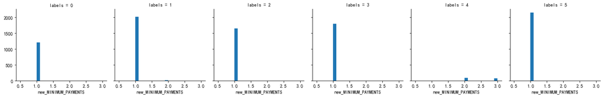

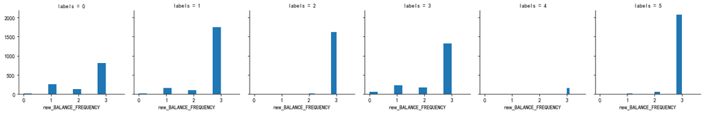

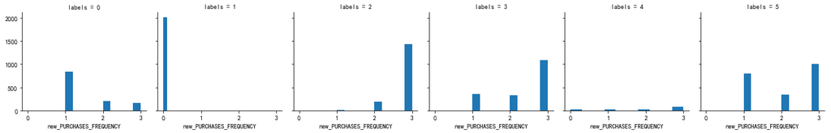

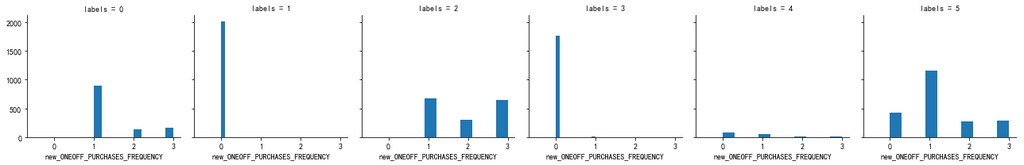

[6 more figures not shown]

```python
for column in df_data:
    grid= sns.FacetGrid(df_data,col='labels')
    grid.map(plt.hist,column)
```

上面的结果有一个问题，就是labels为4时对应的数据很少，只有159条数据，而其他类别的数据都是千位级以上的数据，所以我觉得这类数据是不够规模的，也就没有必要单独提取出来进行分析，所以可以尝试将K设定为5在进行聚类

```python
kmeans = KMeans(4)
kmeans.fit(X)
labels = kmeans.labels_
```

```python
data = pd.concat([data,pd.DataFrame({'labels':labels})],axis=1)
```

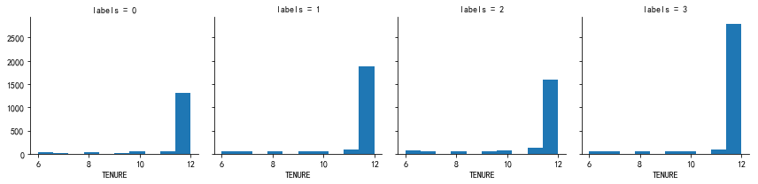

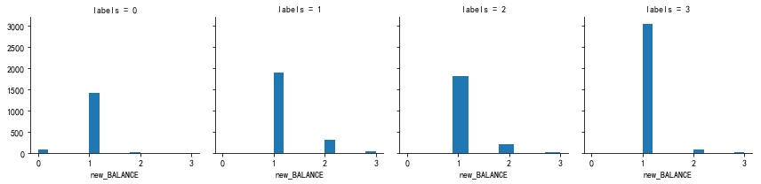

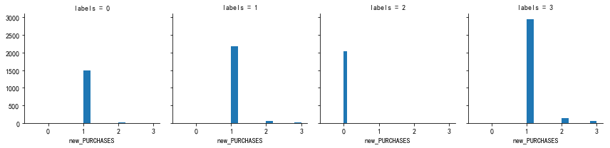

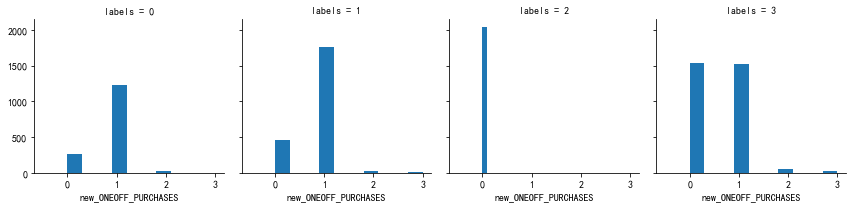

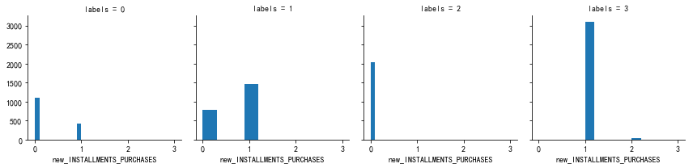

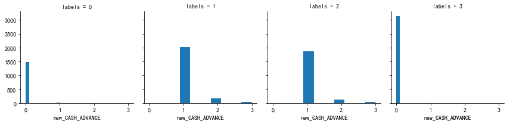

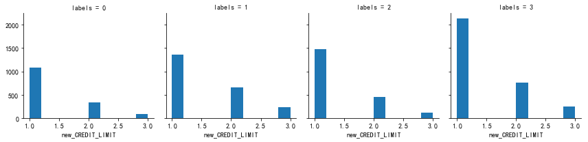

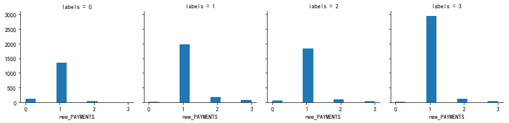

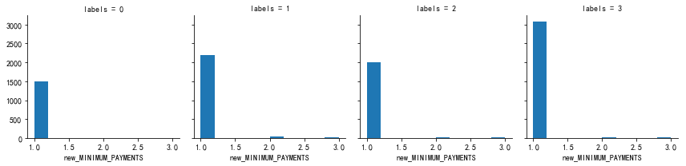

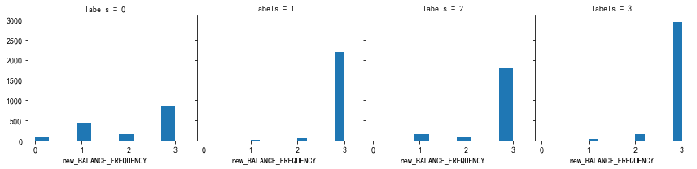

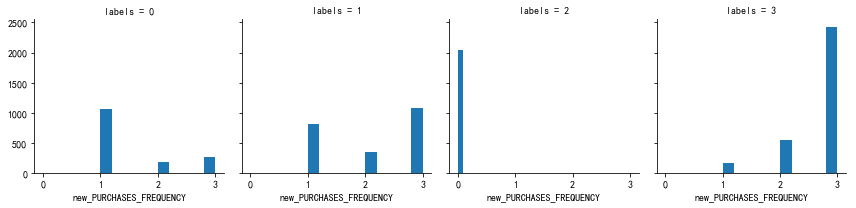

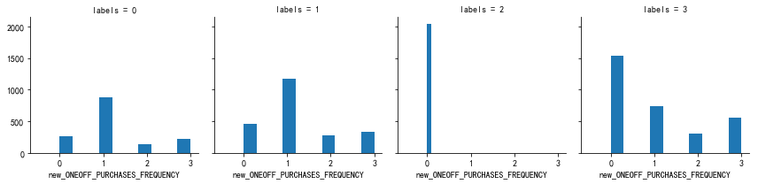

[6 more figures not shown]

```python
for column in data:
    grid= sns.FacetGrid(data,col='labels')
    grid.map(plt.hist,column)
```

- 上面是针对每个簇进行的可视化，可以从中总结出每个群体的一些特点，不过总结的效果也要根据K的选择来决定，如果K设定的不合理，效果会变差

label 0：

- 信用额度比较低，证明这类人群的收入可能并不高；
- 购物频率比较低，证明不喜爱购物；
- 不使用分期的方式进行购物
- 不使用预付消费的方式，可能表名这类人群没有什么固定的购买目标，买的东西会比较杂
- 总结：收入不高，不是很喜欢购物，且没有明确的购买目标，忠诚度不够

label0总结：针对客户的购买喜好推荐价格较低或正在促销的产品。

label 1：

- 从余额，购买频率和余额变动频率可以看出这类人群收入比较高，且喜欢购物；
- 从分期使用频率可以看出，这类人群也比较喜欢分期付款的方式；
- 从预付消费金额和使用频率可以看出，这类人群有使用预付方式进行消费的习惯，说明这类人群更忠诚，喜欢去固定的地点或者习惯的地方进行消费
- 总结：收入较高，且喜欢购物，可以接受分期和预付的方式进行消费，有固定的消费地点或者区域，客户忠诚度高

label1总结：针对购买喜好推荐价格更高的产品，并提供分期的消费方式，还可以针对这类客户制定充值优惠等活动，这样既可以促进消费又可以提高客户忠的诚度

label 2：

- 总结：这类人群不喜欢购物，不喜欢分期，经常使用的消费方式基本都是预付消费

label2总结：针对购买喜好推荐相应产品，并提供充值优惠等活动，这样既可以促进消费又可以提高客户忠的诚度

label 3：

- 总结：收入高，非常喜欢购物，也经常使用分期的方式，可能是购物狂，但没有预付消费的方式，证明没有明确的固定消费地点或区域，客户忠诚度不够

label3总结：针对购买喜好推荐价格更高的各类产品，并提供分期付款的方式，并且对于这类客户可以制定充值等活动来吸纳成为会员，这样既可以促进消费又可以提高客户忠的诚度